# Operating Characteristics of Multiplier Resampling (MR) — FB / MR (IJ) / MR (field) combined

# 12 Estimate distributions

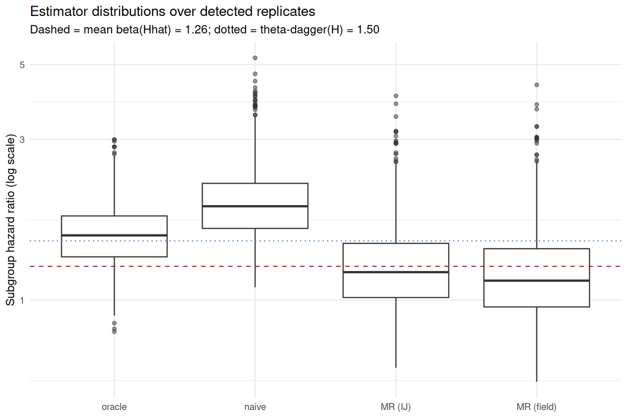

```r
# PORTED FROM THE CONTINUOUS TWIN.  Log scale because these are hazard ratios,
# matching the paired panel; dashed = mean beta(Hhat), dotted = the marginal
# true-region target theta-dagger(H).
.rB <- results[results$detected == 1, , drop = FALSE]
if (nrow(.rB)) {
  est_keys_box <- c(oracle = "or", naive = "nv", FB = "fb", `MR (IJ)` = "mr")
  .long <- do.call(rbind, lapply(names(est_keys_box),
    function(lab) data.frame(Estimator = lab,
                             est = .rB[[paste0(est_keys_box[[lab]], "_H_est")]])))
  .long <- rbind(.long, data.frame(Estimator = "MR (field)", est = .rB$fld_H_est2))
  if (!any(is.finite(.rB$fb_H_est))) .long <- .long[.long$Estimator != "FB", , drop = FALSE]
  .long$Estimator <- factor(.long$Estimator,
                            levels = c("oracle","naive","FB","MR (IJ)","MR (field)"))
  .bH <- .mfin(.rB$betaHhat_H)
  ggplot(.long[is.finite(.long$est) & .long$est > 0, ], aes(x = Estimator, y = est)) +
    geom_boxplot(outlier.alpha = 0.5) +
    geom_hline(yintercept = .bH, linetype = 2, colour = "firebrick") +
    geom_hline(yintercept = truth$marg_H, linetype = 3, colour = "steelblue") +
    scale_y_log10() +
    labs(y = "Subgroup hazard ratio (log scale)", x = NULL,
         title = "Estimator distributions over detected replicates",
         subtitle = sprintf("Dashed = mean beta(Hhat) = %.2f; dotted = theta-dagger(H) = %.2f",
                            .bH, truth$marg_H)) +
    theme_minimal(base_size = 12)
}
```

# 13 The conditional target $\beta(\widehat H)$ vs the oracle

```r
# Narrative companion to the estimation tables: summarises the new conditional
# target beta(Hhat) and contrasts it with the oracle.  Pure consumer of `results`
# (no simulation), reusing the table's per-replicate relative-bias / coverage
# logic, restricted to the harm block where the contrast lives.
if (run_smoke && !is.null(results)) {
  rC <- results[results$detected == 1, , drop = FALSE]
  ok <- is.finite(rC$betaHhat_H)
  if (any(ok)) {
    .relb <- function(est, tgt) { d <- (est - tgt) / tgt; d <- d[is.finite(d)]
                                  if (length(d)) 100 * mean(d) else NA_real_ }
    .covg <- function(tgt, lo, hi) { o <- is.finite(tgt) & is.finite(lo) & is.finite(hi)
                                     if (any(o)) 100 * mean(tgt[o] >= lo[o] & tgt[o] <= hi[o]) else NA_real_ }
    bH  <- rC$betaHhat_H        # realized-region truth (the Theorem 2 target)
    orH <- rC$or_H_est         # oracle: effect at the TRUE region (theta-dagger(H))
    keys <- c(naive = "nv", FB = "fb", MR = "mr")
    if (!run_fb) keys <- keys[names(keys) != "FB"]
    erows <- vapply(names(keys), function(lab) {
      k  <- keys[[lab]]
      e  <- rC[[paste0(k, "_H_est")]]; lo <- rC[[paste0(k, "_H_lo")]]; hi <- rC[[paste0(k, "_H_hi")]]
      sprintf("| %s | %.2f | %+.0f%% | %+.0f%% | %.0f%% | %.0f%% |",
              lab, mean(e[is.finite(e)]), .relb(e, bH), .relb(e, orH),
              .covg(bH, lo, hi), .covg(orH, lo, hi))
    }, character(1))
    mr_m   <- mean(rC$mr_H_est[is.finite(rC$mr_H_est)])
    nearer <- if (isTRUE(abs(mr_m - mean(orH, na.rm = TRUE)) <= abs(mr_m - mean(bH))))
                "the oracle (true-region) effect $\\theta^{\\dagger}(H)$" else "$\\beta(\\widehat H)$"

    cat(sprintf("\n::: {.callout-note title=\"The \u03b2(\u0124) target vs the oracle \u2014 harm block, %d detections\"}\n\n", sum(ok)))
    cat("$\\beta(\\widehat H)$ is the population value of the standard within-subgroup analysis ",
        "(the Cox hazard ratio of treatment) at the **realized** region $\\widehat H$ \u2014 the truth of the ",
        "subgroup the search actually found, and the conditional estimand Theorem 2 certifies. It is a ",
        "*per-replicate* target. The **oracle** $\\hat\\theta(H)$ refits on the **true** region $H$ instead ",
        "(the effect one would estimate knowing the subgroup); their gap is the price of selecting the ",
        "wrong region.\n\n", sep = "")
    cat(sprintf("- $\\beta(\\widehat H)$: mean **%.2f** (median %.2f)  \u00b7  $\\beta(\\widehat H^{c})$: mean %.2f\n",
                mean(bH), stats::median(bH), mean(rC$betaHhat_Hc[is.finite(rC$betaHhat_Hc)])))
    cat(sprintf("- oracle $\\hat\\theta(H)$: mean **%.2f**  (true-region effect $\\theta^{\\dagger}(H) = %.2f$)\n",
                mean(orH, na.rm = TRUE), truth$marg_H))
    cat(sprintf("- discovery gap $\\hat\\theta(H) - \\beta(\\widehat H)$: mean **%.2f**\n\n",
                mean((orH - bH)[is.finite(orH - bH)])))
    cat("| estimator | mean | bias vs $\\beta(\\widehat H)$ | bias vs oracle | cov $\\beta(\\widehat H)$ | cov oracle |\n")
    cat("|:--|--:|--:|--:|--:|--:|\n")
    cat(paste(erows, collapse = "\n"), "\n\n")
    cat(sprintf("In this cell the MR estimate sits nearer %s. ", nearer))
    cat("The *bias vs $\\beta(\\widehat H)$* column is what Theorem 2 speaks to; *bias vs oracle* is distance ",
        "from the true-region effect. ", sep = "")
    cat(sprintf("At %d detections these figures are indicative, not a coverage read.\n", sum(ok)))
    cat("\n:::\n\n")
  }
}
```

**NoteThe β(Ĥ) target vs the oracle — harm block, 1999 detections**

$\beta(\widehat H)$ is the population value of the standard within-subgroup analysis (the Cox hazard ratio of treatment) at the **realized** region $\widehat H$ — the truth of the subgroup the search actually found, and the conditional estimand Theorem 2 certifies. It is a *per-replicate* target. The **oracle** $\hat\theta(H)$ refits on the **true** region $H$ instead (the effect one would estimate knowing the subgroup); their gap is the price of selecting the wrong region.

- $\beta(\widehat H)$: mean **1.26** (median 1.28) · $\beta(\widehat H^{c})$: mean 0.81
- oracle $\hat\theta(H)$: mean **1.59** (true-region effect $\theta^{\dagger}(H) = 1.50$)
- discovery gap $\hat\theta(H) - \beta(\widehat H)$: mean **0.33**

| estimator | mean | bias vs $\beta(\widehat H)$ | bias vs oracle | cov $\beta(\widehat H)$ | cov oracle |
| --- | --- | --- | --- | --- | --- |
| naive | 1.98 | +63% | +27% | 60% | 95% |
| MR | 1.28 | +5% | -19% | 98% | 98% |

In this cell the MR estimate sits nearer $\beta(\widehat H)$. The *bias vs $\beta(\widehat H)$* column is what Theorem 2 speaks to; *bias vs oracle* is distance from the true-region effect. At 1999 detections these figures are indicative, not a coverage read.